# Homework2

Importing the R libraries

```r
library(DESeq2)
library(dplyr)
library(tidyr)
```

```r
library(ggplot2)
library(scales)
library(ggpubr)
library(vsn)
library("pheatmap")
library("vsn")
```

Importing the data

```r
# Import the counts matrix
countsTable <- read.table("counts_matrix.txt", header=TRUE, row.names=1)
head(countsTable)
```

```
##                          C1R1.P1_S256_L007 C1R2_S161_L007 C1R4_S159_L007
## TRINITY_DN69561_c0_g1_i1                 0              0              0
## TRINITY_DN69561_c0_g2_i1                 0              0              0
## TRINITY_DN69542_c0_g1_i1                 0              0              0
## TRINITY_DN69550_c0_g1_i1                 0              0              0
## TRINITY_DN69550_c0_g1_i2                 0              0              0
## TRINITY_DN69522_c0_g1_i1                 0              0              0
##                          C2R1_S157_L007 C2R2_S158_L007 C3R1_S164_L007
## TRINITY_DN69561_c0_g1_i1              0              0              0
## TRINITY_DN69561_c0_g2_i1              0              0              0
## TRINITY_DN69542_c0_g1_i1              0              0              0
## TRINITY_DN69550_c0_g1_i1              0              0              0
## TRINITY_DN69550_c0_g1_i2              0              0              0
## TRINITY_DN69522_c0_g1_i1              0              0              0
##                          C3R3_S166_L007 C3R4_S170_L007 C3R5_S167_L007
## TRINITY_DN69561_c0_g1_i1              0              0              0
## TRINITY_DN69561_c0_g2_i1              0              0              0
## TRINITY_DN69542_c0_g1_i1              0              0              0
## TRINITY_DN69550_c0_g1_i1              0              0              0
## TRINITY_DN69550_c0_g1_i2              0              0              0
## TRINITY_DN69522_c0_g1_i1              0              0              0
##                          C4R2.P1_S257_L007 C4R3_S165_L007 C4R5_S169_L007
## TRINITY_DN69561_c0_g1_i1                 0              0              0
## TRINITY_DN69561_c0_g2_i1                 0              0              0
## TRINITY_DN69542_c0_g1_i1                 0              0              0
## TRINITY_DN69550_c0_g1_i1                 0              0              0
## TRINITY_DN69550_c0_g1_i2                 0              0              0
## TRINITY_DN69522_c0_g1_i1                 0              0              0
##                          T1R2_S152_L007 T1R3_S151_L007 T1R4_S150_L007
## TRINITY_DN69561_c0_g1_i1              0              0              0
## TRINITY_DN69561_c0_g2_i1              0              0              0
## TRINITY_DN69542_c0_g1_i1              0              0              0
## TRINITY_DN69550_c0_g1_i1              0              0              0
## TRINITY_DN69550_c0_g1_i2              0              0              0
## TRINITY_DN69522_c0_g1_i1              0              0              0
##                          T2R2_S162_L007 T2R3_S156_L007 T2R4_S160_L007
## TRINITY_DN69561_c0_g1_i1              0              0              0
## TRINITY_DN69561_c0_g2_i1              0              0              0
## TRINITY_DN69542_c0_g1_i1              0              0              0
## TRINITY_DN69550_c0_g1_i1              0              0              0
## TRINITY_DN69550_c0_g1_i2              0              0              0
## TRINITY_DN69522_c0_g1_i1              0              0              0
##                          T3R2_S163_L007 T3R3_S168_L007 T3R4.P1_S255_L007
## TRINITY_DN69561_c0_g1_i1              0              0                 0
## TRINITY_DN69561_c0_g2_i1              0              0                 0
## TRINITY_DN69542_c0_g1_i1              0              0                 0
## TRINITY_DN69550_c0_g1_i1              0              0                 0
## TRINITY_DN69550_c0_g1_i2              0              0                 0
## TRINITY_DN69522_c0_g1_i1              0              0                 0
##                          T4R2_S155_L007 T4R3_S154_L007 T4R4_S153_L007
## TRINITY_DN69561_c0_g1_i1              0              0              0
## TRINITY_DN69561_c0_g2_i1              0              0              0
## TRINITY_DN69542_c0_g1_i1              0              0              0
## TRINITY_DN69550_c0_g1_i1              0              0              0
## TRINITY_DN69550_c0_g1_i2              0              0              0
## TRINITY_DN69522_c0_g1_i1              0              0              0
```

```r
dim(countsTable)
```

```
## [1] 119438     24
```

```r
countsTableRound <- round(countsTable) # bc DESeq2 doesn't like decimals (and Salmon outputs data with decimals)
head(countsTableRound)
```

```
##                          C1R1.P1_S256_L007 C1R2_S161_L007 C1R4_S159_L007
## TRINITY_DN69561_c0_g1_i1                 0              0              0
## TRINITY_DN69561_c0_g2_i1                 0              0              0
## TRINITY_DN69542_c0_g1_i1                 0              0              0
## TRINITY_DN69550_c0_g1_i1                 0              0              0
## TRINITY_DN69550_c0_g1_i2                 0              0              0
## TRINITY_DN69522_c0_g1_i1                 0              0              0
##                          C2R1_S157_L007 C2R2_S158_L007 C3R1_S164_L007
## TRINITY_DN69561_c0_g1_i1              0              0              0
## TRINITY_DN69561_c0_g2_i1              0              0              0
## TRINITY_DN69542_c0_g1_i1              0              0              0
## TRINITY_DN69550_c0_g1_i1              0              0              0
## TRINITY_DN69550_c0_g1_i2              0              0              0
## TRINITY_DN69522_c0_g1_i1              0              0              0
##                          C3R3_S166_L007 C3R4_S170_L007 C3R5_S167_L007
## TRINITY_DN69561_c0_g1_i1              0              0              0
## TRINITY_DN69561_c0_g2_i1              0              0              0
## TRINITY_DN69542_c0_g1_i1              0              0              0
## TRINITY_DN69550_c0_g1_i1              0              0              0
## TRINITY_DN69550_c0_g1_i2              0              0              0
## TRINITY_DN69522_c0_g1_i1              0              0              0
##                          C4R2.P1_S257_L007 C4R3_S165_L007 C4R5_S169_L007
## TRINITY_DN69561_c0_g1_i1                 0              0              0
## TRINITY_DN69561_c0_g2_i1                 0              0              0
## TRINITY_DN69542_c0_g1_i1                 0              0              0
## TRINITY_DN69550_c0_g1_i1                 0              0              0
## TRINITY_DN69550_c0_g1_i2                 0              0              0
## TRINITY_DN69522_c0_g1_i1                 0              0              0
##                          T1R2_S152_L007 T1R3_S151_L007 T1R4_S150_L007
## TRINITY_DN69561_c0_g1_i1              0              0              0
## TRINITY_DN69561_c0_g2_i1              0              0              0
## TRINITY_DN69542_c0_g1_i1              0              0              0
## TRINITY_DN69550_c0_g1_i1              0              0              0
## TRINITY_DN69550_c0_g1_i2              0              0              0
## TRINITY_DN69522_c0_g1_i1              0              0              0
##                          T2R2_S162_L007 T2R3_S156_L007 T2R4_S160_L007
## TRINITY_DN69561_c0_g1_i1              0              0              0
## TRINITY_DN69561_c0_g2_i1              0              0              0
## TRINITY_DN69542_c0_g1_i1              0              0              0
## TRINITY_DN69550_c0_g1_i1              0              0              0
## TRINITY_DN69550_c0_g1_i2              0              0              0
## TRINITY_DN69522_c0_g1_i1              0              0              0
##                          T3R2_S163_L007 T3R3_S168_L007 T3R4.P1_S255_L007
## TRINITY_DN69561_c0_g1_i1              0              0                 0
## TRINITY_DN69561_c0_g2_i1              0              0                 0
## TRINITY_DN69542_c0_g1_i1              0              0                 0
## TRINITY_DN69550_c0_g1_i1              0              0                 0
## TRINITY_DN69550_c0_g1_i2              0              0                 0
## TRINITY_DN69522_c0_g1_i1              0              0                 0
##                          T4R2_S155_L007 T4R3_S154_L007 T4R4_S153_L007
## TRINITY_DN69561_c0_g1_i1              0              0              0
## TRINITY_DN69561_c0_g2_i1              0              0              0
## TRINITY_DN69542_c0_g1_i1              0              0              0
## TRINITY_DN69550_c0_g1_i1              0              0              0
## TRINITY_DN69550_c0_g1_i2              0              0              0
## TRINITY_DN69522_c0_g1_i1              0              0              0
```

```r
#import the sample description table
conds <- read.delim("metadata.txt", header=TRUE, stringsAsFactors = TRUE, row.names=1)
head(conds)
```

```
##      generation    line
## C1R1         G1 control
## C1R2         G1 control
## C1R4         G1 control
## C2R1         G2 control
## C2R2         G2 control
## C3R1         G3 control
```

Running DESeq2 without the interaction term

```r
####################################################

### Start working with DESeq2!

####################################################


#Correct column names
colnames(countsTableRound) <- substr(colnames(countsTableRound),
                                     start = 1, stop = 4)
#### Create a DESeq object and define the experimental design here with the tilda
dds <- DESeqDataSetFromMatrix(countData = countsTableRound, colData=conds,
                              design= ~ generation + line)
dim(dds)
```

```
## [1] 119438     24
```

```r
# Filter out genes with too few reads - remove all genes with counts < 15 in more than 75% of 24 samples, so 18)
## suggested by WGCNA on RNAseq FAQ

dds <- dds[rowSums(counts(dds) >= 15) >= 18,]
nrow(dds)
```

```
## [1] 14566
```

```r
# How many transcripts have at least 15 reads (a.k.a counts) in 75% of the samples

# Run the DESeq model to test for differential gene expression
dds <- DESeq(dds)
```

```
## -- note: fitType='parametric', but the dispersion trend was not well captured by the
##    function: y = a/x + b, and a local regression fit was automatically substituted.
##    specify fitType='local' or 'mean' to avoid this message next time.
```

```r
# List the results you've generated
resultsNames(dds)
```

```
## [1] "Intercept"                 "generation_G2_vs_G1"
## [3] "generation_G3_vs_G1"       "generation_G4_vs_G1"
## [5] "line_treatment_vs_control"
```

```r
# Copy the results names
```

Running DESeq2 with the interaction term

```r
#### Create a DESeq object and define the experimental design here with the tilda
dds_interaction <- DESeqDataSetFromMatrix(countData = countsTableRound, colData=conds,
                              design= ~ generation + line + generation:line)
dim(dds_interaction)
```

```
## [1] 119438     24
```

```r
# Filter out genes with too few reads - remove all genes with counts < 15 in more than 75% of 24 samples, so 18)
## suggested by WGCNA on RNAseq FAQ

dds_interaction <- dds_interaction[rowSums(counts(dds) >= 15) >= 18,]
nrow(dds_interaction)
```

```
## [1] 119438
```

```r
# How many transcripts have at least 15 reads (a.k.a counts) in 75% of the samples

# Run the DESeq model to test for differential gene expression
dds_interaction <- DESeq(dds_interaction)
# List the results you've generated
resultsNames(dds_interaction)
```

```
## [1] "Intercept"                  "generation_G2_vs_G1"
## [3] "generation_G3_vs_G1"        "generation_G4_vs_G1"
## [5] "line_treatment_vs_control"  "generationG2.linetreatment"
## [7] "generationG3.linetreatment" "generationG4.linetreatment"
```

```r
# Copy the results names
```

Generating PCAs for data without interaction term

```r
# first transform the data for plotting using variance stabilization
vsd <- vst(dds, blind=FALSE)
```

```
## -- note: fitType='parametric', but the dispersion trend was not well captured by the
##    function: y = a/x + b, and a local regression fit was automatically substituted.
##    specify fitType='local' or 'mean' to avoid this message next time.
```

```r
pcaData <- plotPCA(vsd, intgroup=c("line","generation"), returnData=TRUE)
```

```
## using ntop=500 top features by variance
```

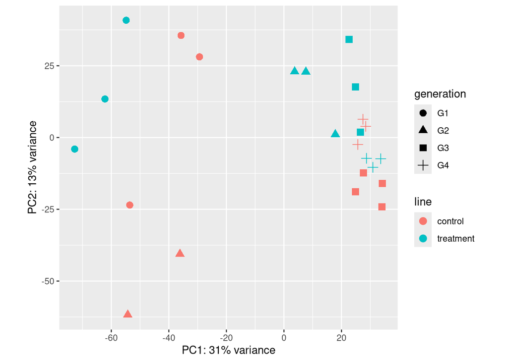

```r
percentVar <- round(100 * attr(pcaData,"percentVar"))

ggplot(pcaData, aes(PC1, PC2, color=line, shape=generation)) +
  geom_point(size=3) +
  xlab(paste0("PC1: ",percentVar[1],"% variance")) +
  ylab(paste0("PC2: ",percentVar[2],"% variance")) +
  coord_fixed()
```

Another way of visualizing the PCA data (alpha value and shape is for generation; blue is control & red is treatment)

```r
p1=ggplot(pcaData, aes(PC1, PC2)) +
  geom_point(size=5, stroke = 1, aes(fill=line, shape=generation)) +
  xlab(paste0("PC1: ",percentVar[1],"% variance")) +
  ylab(paste0("PC2: ",percentVar[2],"% variance")) +
  scale_shape_manual(values=c(21,22,23,24), labels = c("G1", "G2","G3", "G4"))+
  #scale_shape_manual(values=c(21,22,23,24) -> circle, square, diamond, triangle
  scale_fill_manual(values=c('#6699CC',"#CC3333"), labels = c("Control", "Treatment"))+
  scale_alpha_manual(values = c(1.0, 0.8, 0.7, 0.3), guide = "none") +
  theme_bw() +
  theme(legend.position = "none") +
  theme(panel.border = element_rect(color = "black", fill = NA, size = 3))+
  theme(text = element_text(size = 20)) +
  theme(legend.title = element_blank())
```

PCAs for DESeq2 with the interaction term

```r
# first transform the data for plotting using variance stabilization
vsd <- vst(dds_interaction, blind=FALSE)

pcaData1 <- plotPCA(vsd, intgroup=c("line","generation"), returnData=TRUE)
```

```
## using ntop=500 top features by variance
```

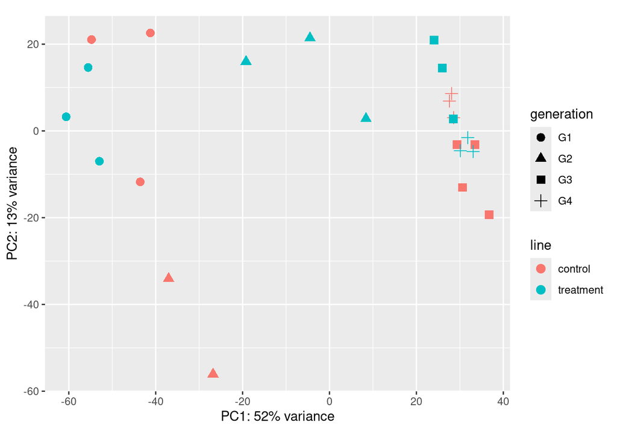

```r
percentVar <- round(100 * attr(pcaData1,"percentVar"))

ggplot(pcaData1, aes(PC1, PC2, color=line, shape=generation)) +
  geom_point(size=3) +
  xlab(paste0("PC1: ",percentVar[1],"% variance")) +
  ylab(paste0("PC2: ",percentVar[2],"% variance")) +
  coord_fixed()
```

Another way of visualizing the PCA data (alpha value and shape is for generation; blue is control & red is treatment)

```r
p2=ggplot(pcaData1, aes(PC1, PC2)) +
  geom_point(aes(fill = line, shape = generation),
             size = 5, stroke = 1, color = "black", show.legend = TRUE) +
  xlab(paste0("PC1: ", percentVar[1], "% variance")) +
  ylab(paste0("PC2: ", percentVar[2], "% variance")) +
  scale_shape_manual(values = c(21, 22, 23, 24), labels = c("G1", "G2", "G3", "G4")) +
  scale_fill_manual(values = c('#6699CC', '#CC3333'), labels = c("Control", "Treatment")) +
  guides(
    fill = guide_legend(override.aes = list(shape = 21, color = "black", alpha = 1))
  ) +
  theme_bw() +
  theme(
    panel.border = element_rect(color = "black", fill = NA, size = 3),
    text = element_text(size = 20),
    legend.title = element_blank()
  )
```

Making the double panel plot and saving it for the write-up

```r
Fig1=ggarrange(p1, p2, ncol = 2, nrow = 1, heights = c(1,1), widths = c(1,1.3))

ggsave("Fig1.jpeg", width = 11, height = 4)
```

Testing for differential gene expression using the group model Staring with the model without interaction between generation and line

```r
dds$line <- relevel(dds$line, ref = "control")
dds$generation <- relevel(dds$generation, ref = "G1")


dds$group <- factor(paste0(dds$line, dds$generation))
design(dds) <- ~ group
dds <- DESeq(dds)
```

```
## found already estimated dispersions, replacing these
```

```
## -- note: fitType='parametric', but the dispersion trend was not well captured by the
##    function: y = a/x + b, and a local regression fit was automatically substituted.
##    specify fitType='local' or 'mean' to avoid this message next time.
```

```r
resultsNames(dds)
```

```
## [1] "Intercept"                      "group_controlG2_vs_controlG1"
## [3] "group_controlG3_vs_controlG1"   "group_controlG4_vs_controlG1"
## [5] "group_treatmentG1_vs_controlG1" "group_treatmentG2_vs_controlG1"
## [7] "group_treatmentG3_vs_controlG1" "group_treatmentG4_vs_controlG1"
```

```r
resG1_CvT <- results(dds, contrast=c("group","controlG1","treatmentG1"), alpha = 0.05)

summary(resG1_CvT)
```

```
##
## out of 14566 with nonzero total read count
## adjusted p-value < 0.05
## LFC > 0 (up)       : 308, 2.1%
## LFC < 0 (down)     : 265, 1.8%
## outliers [1]       : 7, 0.048%
## low counts [2]     : 0, 0%
## (mean count < 15)
## [1] see 'cooksCutoff' argument of ?results
## [2] see 'independentFiltering' argument of ?results
```

Re-order the genes by significance

```r
resG1_CvT <- resG1_CvT[order(resG1_CvT$padj),]
head(resG1_CvT)
```

```
## log2 fold change (MLE): group controlG1 vs treatmentG1
## Wald test p-value: group controlG1 vs treatmentG1
## DataFrame with 6 rows and 6 columns
##                               baseMean log2FoldChange     lfcSE      stat
##                              <numeric>      <numeric> <numeric> <numeric>
## TRINITY_DN139369_c0_g5_i1      82.3230       20.92035  1.588796  13.16743
## TRINITY_DN93941_c0_g3_i1   208287.8124        7.57130  0.598321  12.65425
## TRINITY_DN136145_c6_g8_i4     261.7359        4.90195  0.599290   8.17960
## TRINITY_DN151449_c2_g3_i1     142.3578        3.67963  0.504642   7.29158
## TRINITY_DN151169_c8_g9_i1     432.3605       -1.99231  0.276783  -7.19809
## TRINITY_DN148336_c14_g7_i1     39.6947       -4.47426  0.667075  -6.70728
##                                 pvalue        padj
##                              <numeric>   <numeric>
## TRINITY_DN139369_c0_g5_i1  1.35125e-39 1.96728e-35
## TRINITY_DN93941_c0_g3_i1   1.05988e-36 7.71542e-33
## TRINITY_DN136145_c6_g8_i4  2.84786e-16 1.38207e-12
## TRINITY_DN151449_c2_g3_i1  3.06345e-13 1.11502e-09
## TRINITY_DN151169_c8_g9_i1  6.10625e-13 1.77802e-09
## TRINITY_DN148336_c14_g7_i1 1.98284e-11 4.81136e-08
```

Selected gene TRINITY_DN139369_c0_g5_i1 from the previous output

```r
# Counts of specific top interaction gene! (important validation that the normalization, model is working)
d <-plotCounts(dds, gene="TRINITY_DN139369_c0_g5_i1", intgroup = (c("line","generation")), returnData=TRUE)
d
```

```
##          count      line generation
## C1R1   0.50000   control         G1
## C1R2   0.50000   control         G1
## C1R4  91.63869   control         G1
## C2R1  59.15264   control         G2
## C2R2  21.59041   control         G2
## C3R1  99.32316   control         G3
## C3R3  95.10213   control         G3
## C3R4 102.11241   control         G3
## C3R5  92.37040   control         G3
## C4R2  75.29341   control         G4
## C4R3 114.15924   control         G4
## C4R5 105.58920   control         G4
## T1R2   0.50000 treatment         G1
## T1R3   0.50000 treatment         G1
## T1R4   0.50000 treatment         G1
## T2R2  94.36963 treatment         G2
## T2R3 156.99509 treatment         G2
## T2R4 201.46237 treatment         G2
## T3R2  94.27850 treatment         G3
## T3R3 125.52742 treatment         G3
## T3R4 160.79377 treatment         G3
## T4R2 114.30661 treatment         G4
## T4R3  88.78973 treatment         G4
## T4R4  92.39630 treatment         G4
```

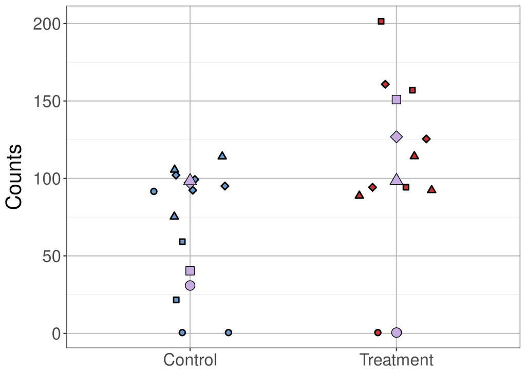

```r
d$line <- factor(d$line, levels = c("control", "treatment"),
                 labels = c("Control", "Treatment"))

p1 <-ggplot(d, aes(x=line, y=count, fill=line, shape=generation)) +
  theme_bw() + theme(text = element_text(size=20), panel.grid.major=element_line(colour="grey")) +
  scale_shape_manual(values = c(21, 22, 23, 24), labels = c("G1", "G2", "G3", "G4"), name="Generation") +
  scale_fill_manual(
    values = c("Control" = "#6699CC", "Treatment" = "#CC3333"),
    name = "Line"
  ) +
   guides(
    shape = guide_legend(override.aes = list(fill="white", color="black")),
    fill  = guide_legend(override.aes = list(shape=21, color="black"))
  )
p1 <- p1 + geom_point(mapping = aes(fill = line),
                    position=position_jitter(w=0.2,h=0), size=2, color= "black", show.legend = TRUE, stroke=1)
p1 <- p1 + stat_summary(fun = mean, geom = "point", size=4, fill="#c6abe0", color="black") + labs(x=NULL, y="Counts") + theme(legend.position = "none")+ theme(
  axis.title.y = element_text(margin = margin(r = 7)))
p1
```

Testing for differential gene expression using the group model Staring with the model with interaction between generation and line

```r
dds_interaction$line <- relevel(dds_interaction$line, ref = "control")
dds_interaction$generation <- relevel(dds_interaction$generation, ref = "G1")


dds_interaction$group <- factor(paste0(dds_interaction$line, dds_interaction$generation))
design(dds_interaction) <- ~ group
dds_interaction <- DESeq(dds_interaction)
```

```
## found already estimated dispersions, replacing these
```

```r
resultsNames(dds_interaction)
```

```
## [1] "Intercept"                      "group_controlG2_vs_controlG1"
## [3] "group_controlG3_vs_controlG1"   "group_controlG4_vs_controlG1"
## [5] "group_treatmentG1_vs_controlG1" "group_treatmentG2_vs_controlG1"
## [7] "group_treatmentG3_vs_controlG1" "group_treatmentG4_vs_controlG1"
```

```r
resG1_CvT <- results(dds_interaction, contrast=c("group","controlG1","treatmentG1"), alpha = 0.05)

summary(resG1_CvT)
```

```
##
## out of 81541 with nonzero total read count
## adjusted p-value < 0.05
## LFC > 0 (up)       : 253, 0.31%
## LFC < 0 (down)     : 218, 0.27%
## outliers [1]       : 191, 0.23%
## low counts [2]     : 58457, 72%
## (mean count < 13)
## [1] see 'cooksCutoff' argument of ?results
## [2] see 'independentFiltering' argument of ?results
```

Re-order the genes by significance

```r
resG1_CvT <- resG1_CvT[order(resG1_CvT$padj),]
head(resG1_CvT)
```

```
## log2 fold change (MLE): group controlG1 vs treatmentG1
## Wald test p-value: group controlG1 vs treatmentG1
## DataFrame with 6 rows and 6 columns
##                               baseMean log2FoldChange     lfcSE      stat
##                              <numeric>      <numeric> <numeric> <numeric>
## TRINITY_DN139369_c0_g5_i1      82.0057        21.0948  1.550768  13.60283
## TRINITY_DN143182_c0_g2_i3     112.3192        22.3085  1.703882  13.09277
## TRINITY_DN93941_c0_g3_i1   207760.1809         7.5476  0.612245  12.32776
## TRINITY_DN139743_c0_g6_i4      47.4134        21.6557  1.890973  11.45214
## TRINITY_DN148471_c2_g14_i2     64.6758        20.6308  1.924990  10.71733
## TRINITY_DN129984_c5_g8_i3      46.4458       -19.1278  2.000302  -9.56244
##                                 pvalue        padj
##                              <numeric>   <numeric>
## TRINITY_DN139369_c0_g5_i1  3.85220e-42 8.81883e-38
## TRINITY_DN143182_c0_g2_i3  3.62161e-39 4.14547e-35
## TRINITY_DN93941_c0_g3_i1   6.42082e-35 4.89973e-31
## TRINITY_DN139743_c0_g6_i4  2.29415e-30 1.31300e-26
## TRINITY_DN148471_c2_g14_i2 8.44038e-27 3.86451e-23
## TRINITY_DN129984_c5_g8_i3  1.15007e-21 4.38809e-18
```

Selected gene TRINITY_DN139369_c0_g5_i1 from the previous output

```r
# Counts of specific top interaction gene! (important validation that the normalization, model is working)
d <-plotCounts(dds_interaction, gene="TRINITY_DN139369_c0_g5_i1", intgroup = (c("line","generation")), returnData=TRUE)
d
```

```
##          count      line generation
## C1R1   0.50000   control         G1
## C1R2   0.50000   control         G1
## C1R4  88.17279   control         G1
## C2R1  57.52366   control         G2
## C2R2  21.04295   control         G2
## C3R1  98.61578   control         G3
## C3R3  93.95023   control         G3
## C3R4 100.88757   control         G3
## C3R5  92.13217   control         G3
## C4R2  73.96925   control         G4
## C4R3 114.41910   control         G4
## C4R5 106.36874   control         G4
## T1R2   0.50000 treatment         G1
## T1R3   0.50000 treatment         G1
## T1R4   0.50000 treatment         G1
## T2R2  94.50310 treatment         G2
## T2R3 158.49850 treatment         G2
## T2R4 199.53442 treatment         G2
## T3R2  93.80435 treatment         G3
## T3R3 126.00282 treatment         G3
## T3R4 163.15249 treatment         G3
## T4R2 114.74280 treatment         G4
## T4R3  88.41550 treatment         G4
## T4R4  91.90032 treatment         G4
```

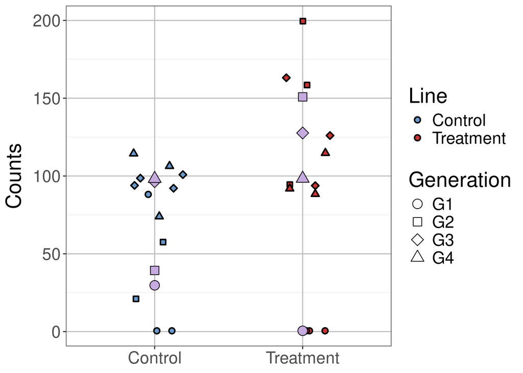

```r
d$line <- factor(d$line, levels = c("control", "treatment"),
                 labels = c("Control", "Treatment"))

p2 <-ggplot(d, aes(x=line, y=count, fill=line, shape=generation)) +
  theme_bw() + theme(text = element_text(size=20), panel.grid.major=element_line(colour="grey")) +
  scale_shape_manual(values = c(21, 22, 23, 24), labels = c("G1", "G2", "G3", "G4"), name="Generation") +
  scale_fill_manual(
    values = c("Control" = "#6699CC", "Treatment" = "#CC3333"),
    name = "Line"
  ) +
   guides(
    shape = guide_legend(override.aes = list(fill="white", color="black")),
    fill  = guide_legend(override.aes = list(shape=21, color="black"))
  )
p2 <- p2 + geom_point(mapping = aes(fill = line),
                    position=position_jitter(w=0.2,h=0), size=2, color= "black", show.legend = TRUE, stroke=1)
p2 <- p2 + stat_summary(fun = mean, geom = "point", size=4, fill="#c6abe0", color="black") + labs(x=NULL, y="Counts")+ theme(
  axis.title.y = element_text(margin = margin(r = 7)))
p2
```

Trying another gene TRINITY_DN93941_c0_g3_i1 without interaction

```r
# Counts of specific top interaction gene! (important validation that the normalization, model is working)
d <-plotCounts(dds, gene="TRINITY_DN93941_c0_g3_i1", intgroup = (c("line","generation")), returnData=TRUE)
d
```

```
##            count      line generation
## C1R1  98570.4212   control         G1
## C1R2  69746.7654   control         G1
## C1R4  44932.5124   control         G1
## C2R1   1595.4734   control         G2
## C2R2  16594.7006   control         G2
## C3R1 327882.1608   control         G3
## C3R3 311491.2009   control         G3
## C3R4 224632.2124   control         G3
## C3R5 416171.7719   control         G3
## C4R2 206037.2943   control         G4
## C4R3 395511.1629   control         G4
## C4R5 345964.3787   control         G4
## T1R2    428.4363 treatment         G1
## T1R3    103.1180 treatment         G1
## T1R4    590.3878 treatment         G1
## T2R2 264441.9290 treatment         G2
## T2R3 217745.9188 treatment         G2
## T2R4 156862.3172 treatment         G2
## T3R2 223851.6625 treatment         G3
## T3R3 355873.7267 treatment         G3
## T3R4 350648.0700 treatment         G3
## T4R2 310628.9372 treatment         G4
## T4R3 383781.0106 treatment         G4
## T4R4 274833.9278 treatment         G4
```

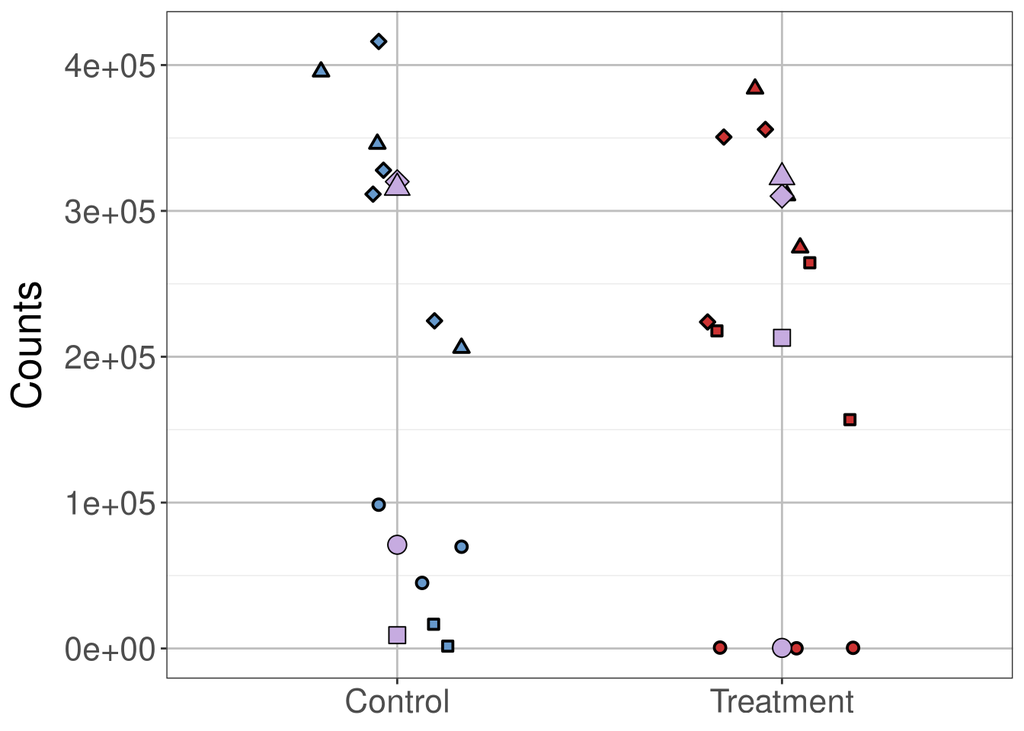

```r
d$line <- factor(d$line, levels = c("control", "treatment"),
                 labels = c("Control", "Treatment"))

p3 <-ggplot(d, aes(x=line, y=count, fill=line, shape=generation)) +
  theme_bw() + theme(text = element_text(size=20), panel.grid.major=element_line(colour="grey")) +
  scale_shape_manual(values = c(21, 22, 23, 24), labels = c("G1", "G2", "G3", "G4"), name="Generation") +
  scale_fill_manual(
    values = c("Control" = "#6699CC", "Treatment" = "#CC3333"),
    name = "Line"
  ) +
   guides(
    shape = guide_legend(override.aes = list(fill="white", color="black")),
    fill  = guide_legend(override.aes = list(shape=21, color="black"))
  )
p3 <- p3 + geom_point(mapping = aes(fill = line),
                    position=position_jitter(w=0.2,h=0), size=2, color= "black", show.legend = TRUE, stroke=1)
p3 <- p3 + stat_summary(fun = mean, geom = "point", size=4, fill="#c6abe0", color="black") + labs(x=NULL, y="Counts")+ theme(legend.position = "none")+ theme(
  axis.title.y = element_text(margin = margin(r = 7)))
p3
```

Adding in the interaction

```r
# Counts of specific top interaction gene! (important validation that the normalization, model is working)
d <-plotCounts(dds_interaction, gene="TRINITY_DN93941_c0_g3_i1", intgroup = (c("line","generation")), returnData=TRUE)
d
```

```
##            count      line generation
## C1R1  94458.0522   control         G1
## C1R2  69075.0394   control         G1
## C1R4  43223.7996   control         G1
## C2R1   1551.1756   control         G2
## C2R2  16163.9530   control         G2
## C3R1 325535.1574   control         G3
## C3R3 307698.3931   control         G3
## C3R4 221924.4860   control         G3
## C3R5 415092.6090   control         G3
## C4R2 202389.5862   control         G4
## C4R3 396415.4302   control         G4
## C4R5 348530.7129   control         G4
## T1R2    420.6134 treatment         G1
## T1R3    101.5355 treatment         G1
## T1R4    583.7017 treatment         G1
## T2R2 264817.9344 treatment         G2
## T2R3 219837.7415 treatment         G2
## T2R4 155357.4544 treatment         G2
## T3R2 222719.8571 treatment         G3
## T3R3 357226.8990 treatment         G3
## T3R4 355807.8335 treatment         G3
## T4R2 311819.4907 treatment         G4
## T4R3 382154.2905 treatment         G4
## T4R4 273350.5951 treatment         G4
```

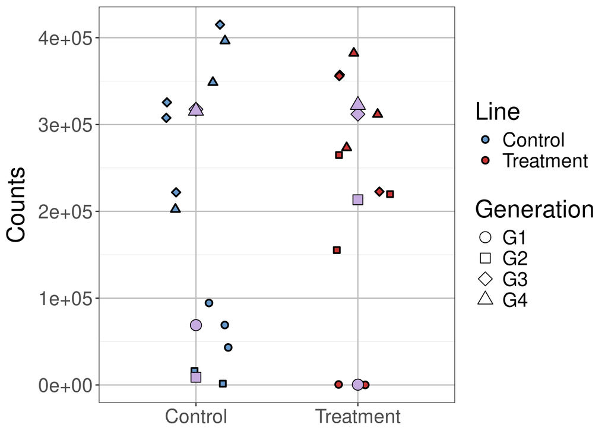

```r
d$line <- factor(d$line, levels = c("control", "treatment"),
                 labels = c("Control", "Treatment"))

p4 <-ggplot(d, aes(x=line, y=count, fill=line, shape=generation)) +
  theme_bw() + theme(text = element_text(size=20), panel.grid.major=element_line(colour="grey")) +
  scale_shape_manual(values = c(21, 22, 23, 24), labels = c("G1", "G2", "G3", "G4"), name="Generation") +
  scale_fill_manual(
    values = c("Control" = "#6699CC", "Treatment" = "#CC3333"),
    name = "Line"
  ) +
   guides(
    shape = guide_legend(override.aes = list(fill="white", color="black")),
    fill  = guide_legend(override.aes = list(shape=21, color="black"))
  )
p4 <- p4 + geom_point(mapping = aes(fill = line),
                    position=position_jitter(w=0.2,h=0), size=2, color= "black", show.legend = TRUE, stroke=1)
p4 <- p4 + stat_summary(fun = mean, geom = "point", size=4, fill="#c6abe0", color="black") + labs(x=NULL, y="Counts")+ theme(
  axis.title.y = element_text(margin = margin(r = 7)))
p4
```

Making the double panel plot and saving it for the write-up

[figure not shown]

```r
Fig2=ggarrange(p1, p2, p3, p4, ncol = 2, nrow = 2, heights = c(1,1), widths = c(1,1.3))
annotate_figure(Fig2,
                left = "TRINITY_DN139369_c0_g5_i1                   TRINITY_DN93941_c0_g3_i1")
```

```r
ggsave("Fig2.jpeg", width = 14, height = 8)
```

Setting up the data for the Euler Plots without interactions

```r
#Gen1
resG1_CvT <- results(dds, contrast=c("group","controlG1","treatmentG1"), alpha = 0.05)
resG1_CvT <- resG1_CvT[order(resG1_CvT$padj),] #sort
head(resG1_CvT)
```

```
## log2 fold change (MLE): group controlG1 vs treatmentG1
## Wald test p-value: group controlG1 vs treatmentG1
## DataFrame with 6 rows and 6 columns
##                               baseMean log2FoldChange     lfcSE      stat
##                              <numeric>      <numeric> <numeric> <numeric>
## TRINITY_DN139369_c0_g5_i1      82.3230       20.92035  1.588796  13.16743
## TRINITY_DN93941_c0_g3_i1   208287.8124        7.57130  0.598321  12.65425
## TRINITY_DN136145_c6_g8_i4     261.7359        4.90195  0.599290   8.17960
## TRINITY_DN151449_c2_g3_i1     142.3578        3.67963  0.504642   7.29158
## TRINITY_DN151169_c8_g9_i1     432.3605       -1.99231  0.276783  -7.19809
## TRINITY_DN148336_c14_g7_i1     39.6947       -4.47426  0.667075  -6.70728
##                                 pvalue        padj
##                              <numeric>   <numeric>
## TRINITY_DN139369_c0_g5_i1  1.35125e-39 1.96728e-35
## TRINITY_DN93941_c0_g3_i1   1.05988e-36 7.71542e-33
## TRINITY_DN136145_c6_g8_i4  2.84786e-16 1.38207e-12
## TRINITY_DN151449_c2_g3_i1  3.06345e-13 1.11502e-09
## TRINITY_DN151169_c8_g9_i1  6.10625e-13 1.77802e-09
## TRINITY_DN148336_c14_g7_i1 1.98284e-11 4.81136e-08
```

```r
summary(resG1_CvT)
```

```
##
## out of 14566 with nonzero total read count
## adjusted p-value < 0.05
## LFC > 0 (up)       : 308, 2.1%
## LFC < 0 (down)     : 265, 1.8%
## outliers [1]       : 7, 0.048%
## low counts [2]     : 0, 0%
## (mean count < 15)
## [1] see 'cooksCutoff' argument of ?results
## [2] see 'independentFiltering' argument of ?results
```

```r
resG1_CvT <- resG1_CvT[!is.na(resG1_CvT$padj),]
degs_G1_CvTM <- row.names(resG1_CvT[resG1_CvT$padj < 0.05,])
```

```r
#Gen2
resG2_CvT <- results(dds, contrast=c("group","controlG2","treatmentG2"), alpha = 0.05)
resG2_CvT <- resG2_CvT[order(resG2_CvT$padj),] #sort
head(resG2_CvT)
```

```
## log2 fold change (MLE): group controlG2 vs treatmentG2
## Wald test p-value: group controlG2 vs treatmentG2
## DataFrame with 6 rows and 6 columns
##                             baseMean log2FoldChange     lfcSE      stat
##                            <numeric>      <numeric> <numeric> <numeric>
## TRINITY_DN146976_c0_g5_i2   248.2963      -23.59064  2.428972  -9.71219
## TRINITY_DN151543_c1_g1_i1    68.0392      -21.54784  2.210866  -9.74633
## TRINITY_DN117930_c0_g1_i1   108.7023        5.08392  0.534409   9.51316
## TRINITY_DN136988_c0_g8_i1   148.0360        3.39891  0.407644   8.33794
## TRINITY_DN133971_c0_g13_i1  532.8910        4.91091  0.595123   8.25193
## TRINITY_DN132222_c1_g8_i1  5126.0570       -3.11790  0.383389  -8.13248
##                                 pvalue        padj
##                              <numeric>   <numeric>
## TRINITY_DN146976_c0_g5_i2  2.67531e-22 1.94749e-18
## TRINITY_DN151543_c1_g1_i1  1.91250e-22 1.94749e-18
## TRINITY_DN117930_c0_g1_i1  1.84954e-21 8.97581e-18
## TRINITY_DN136988_c0_g8_i1  7.55955e-17 2.75149e-13
## TRINITY_DN133971_c0_g13_i1 1.55852e-16 4.53810e-13
## TRINITY_DN132222_c1_g8_i1  4.20610e-16 1.02061e-12
```

```r
summary(resG2_CvT)
```

```
##
## out of 14566 with nonzero total read count
## adjusted p-value < 0.05
## LFC > 0 (up)       : 1980, 14%
## LFC < 0 (down)     : 2588, 18%
## outliers [1]       : 7, 0.048%
## low counts [2]     : 0, 0%
## (mean count < 15)
## [1] see 'cooksCutoff' argument of ?results
## [2] see 'independentFiltering' argument of ?results
```

```r
resG2_CvT <- resG2_CvT[!is.na(resG2_CvT$padj),]
degs_G2_CvTM <- row.names(resG2_CvT[resG2_CvT$padj < 0.05,])
```

```r
#Gen3
resG3_CvT <- results(dds, contrast=c("group","controlG3","treatmentG3"), alpha = 0.05)
resG3_CvT <- resG3_CvT[order(resG3_CvT$padj),] #sort
head(resG3_CvT)
```

```
## log2 fold change (MLE): group controlG3 vs treatmentG3
## Wald test p-value: group controlG3 vs treatmentG3
## DataFrame with 6 rows and 6 columns
##                            baseMean log2FoldChange     lfcSE      stat
##                           <numeric>      <numeric> <numeric> <numeric>
## TRINITY_DN139913_c0_g2_i1  445.7399       -3.81116  0.497828  -7.65558
## TRINITY_DN133387_c3_g9_i5  131.0655        5.01466  0.658437   7.61600
## TRINITY_DN142673_c0_g3_i1  107.4797       -1.50857  0.197618  -7.63379
## TRINITY_DN151311_c3_g1_i2  260.5312       -2.58202  0.364639  -7.08102
## TRINITY_DN135640_c0_g2_i1   66.1181        8.51418  1.224039   6.95581
## TRINITY_DN148386_c0_g4_i1  425.1150       -3.20110  0.458797  -6.97716
##                                pvalue        padj
##                             <numeric>   <numeric>
## TRINITY_DN139913_c0_g2_i1 1.92442e-14 1.24512e-10
## TRINITY_DN133387_c3_g9_i5 2.61652e-14 1.24512e-10
## TRINITY_DN142673_c0_g3_i1 2.27953e-14 1.24512e-10
## TRINITY_DN151311_c3_g1_i2 1.43096e-12 5.10708e-09
## TRINITY_DN135640_c0_g2_i1 3.50550e-12 8.34076e-09
## TRINITY_DN148386_c0_g4_i1 3.01207e-12 8.34076e-09
```

```r
summary(resG3_CvT)
```

```
##
## out of 14566 with nonzero total read count
## adjusted p-value < 0.05
## LFC > 0 (up)       : 832, 5.7%
## LFC < 0 (down)     : 402, 2.8%
## outliers [1]       : 7, 0.048%
## low counts [2]     : 283, 1.9%
## (mean count < 22)
## [1] see 'cooksCutoff' argument of ?results
## [2] see 'independentFiltering' argument of ?results
```

```r
resG3_CvT <- resG3_CvT[!is.na(resG3_CvT$padj),]
degs_G3_CvTM <- row.names(resG3_CvT[resG3_CvT$padj < 0.05,])
```

```r
#Gen4
resG4_CvT <- results(dds, contrast=c("group","controlG4","treatmentG4"), alpha = 0.05)
resG4_CvT <- resG4_CvT[order(resG4_CvT$padj),] #sort
head(resG4_CvT)
```

```
## log2 fold change (MLE): group controlG4 vs treatmentG4
## Wald test p-value: group controlG4 vs treatmentG4
## DataFrame with 6 rows and 6 columns
##                             baseMean log2FoldChange     lfcSE      stat
##                            <numeric>      <numeric> <numeric> <numeric>
## TRINITY_DN106908_c0_g4_i2  2506.5209        3.48507  0.566412   6.15290
## TRINITY_DN133002_c1_g20_i1 3554.9478       11.72727  1.966518   5.96347
## TRINITY_DN148386_c0_g13_i2  305.7184        3.06836  0.524589   5.84909
## TRINITY_DN134030_c0_g6_i1   164.0495        2.89173  0.561913   5.14621
## TRINITY_DN146386_c0_g12_i1   30.7135        2.11879  0.427354   4.95794
## TRINITY_DN137535_c0_g3_i1    86.0985        5.28321  1.070440   4.93555
##                                 pvalue        padj
##                              <numeric>   <numeric>
## TRINITY_DN106908_c0_g4_i2  7.60800e-10 1.10765e-05
## TRINITY_DN133002_c1_g20_i1 2.46933e-09 1.79755e-05
## TRINITY_DN148386_c0_g13_i2 4.94281e-09 2.39874e-05
## TRINITY_DN134030_c0_g6_i1  2.65800e-07 9.67445e-04
## TRINITY_DN146386_c0_g12_i1 7.12459e-07 1.93937e-03
## TRINITY_DN137535_c0_g3_i1  7.99246e-07 1.93937e-03
```

```r
summary(resG4_CvT)
```

```
##
## out of 14566 with nonzero total read count
## adjusted p-value < 0.05
## LFC > 0 (up)       : 38, 0.26%
## LFC < 0 (down)     : 2, 0.014%
## outliers [1]       : 7, 0.048%
## low counts [2]     : 0, 0%
## (mean count < 15)
## [1] see 'cooksCutoff' argument of ?results
## [2] see 'independentFiltering' argument of ?results
```

```r
resG4_CvT <- resG4_CvT[!is.na(resG4_CvT$padj),]
degs_G4_CvTM <- row.names(resG4_CvT[resG4_CvT$padj < 0.05,])
```

Setting up the data for the DESeq2 run with the interactions

```r
#Gen1
resG1_CvT_int <- results(dds_interaction, contrast=c("group","controlG1","treatmentG1"), alpha = 0.05)
resG1_CvT_int <- resG1_CvT_int[order(resG1_CvT_int$padj),] #sort
head(resG1_CvT_int)
```

```
## log2 fold change (MLE): group controlG1 vs treatmentG1
## Wald test p-value: group controlG1 vs treatmentG1
## DataFrame with 6 rows and 6 columns
##                               baseMean log2FoldChange     lfcSE      stat
##                              <numeric>      <numeric> <numeric> <numeric>
## TRINITY_DN139369_c0_g5_i1      82.0057        21.0948  1.550768  13.60283
## TRINITY_DN143182_c0_g2_i3     112.3192        22.3085  1.703882  13.09277
## TRINITY_DN93941_c0_g3_i1   207760.1809         7.5476  0.612245  12.32776
## TRINITY_DN139743_c0_g6_i4      47.4134        21.6557  1.890973  11.45214
## TRINITY_DN148471_c2_g14_i2     64.6758        20.6308  1.924990  10.71733
## TRINITY_DN129984_c5_g8_i3      46.4458       -19.1278  2.000302  -9.56244
##                                 pvalue        padj
##                              <numeric>   <numeric>
## TRINITY_DN139369_c0_g5_i1  3.85220e-42 8.81883e-38
## TRINITY_DN143182_c0_g2_i3  3.62161e-39 4.14547e-35
## TRINITY_DN93941_c0_g3_i1   6.42082e-35 4.89973e-31
## TRINITY_DN139743_c0_g6_i4  2.29415e-30 1.31300e-26
## TRINITY_DN148471_c2_g14_i2 8.44038e-27 3.86451e-23
## TRINITY_DN129984_c5_g8_i3  1.15007e-21 4.38809e-18
```

```r
summary(resG1_CvT_int)
```

```
##
## out of 81541 with nonzero total read count
## adjusted p-value < 0.05
## LFC > 0 (up)       : 253, 0.31%
## LFC < 0 (down)     : 218, 0.27%
## outliers [1]       : 191, 0.23%
## low counts [2]     : 58457, 72%
## (mean count < 13)
## [1] see 'cooksCutoff' argument of ?results
## [2] see 'independentFiltering' argument of ?results
```

```r
resG1_CvT_int <- resG1_CvT_int[!is.na(resG1_CvT_int$padj),]
degs_G1_CvTM_int <- row.names(resG1_CvT_int[resG1_CvT_int$padj < 0.05,])
```

```r
#Gen2
resG2_CvT_int <- results(dds_interaction, contrast=c("group","controlG2","treatmentG2"), alpha = 0.05)
resG2_CvT_int <- resG2_CvT_int[order(resG2_CvT_int$padj),] #sort
head(resG2_CvT_int)
```

```
## log2 fold change (MLE): group controlG2 vs treatmentG2
## Wald test p-value: group controlG2 vs treatmentG2
## DataFrame with 6 rows and 6 columns
##                             baseMean log2FoldChange     lfcSE      stat
##                            <numeric>      <numeric> <numeric> <numeric>
## TRINITY_DN141376_c1_g1_i6    56.5256        49.0261   3.09793   15.8254
## TRINITY_DN126591_c0_g2_i2    24.8127       -42.6114   2.78562  -15.2969
## TRINITY_DN138179_c0_g15_i1   20.2819       -37.8477   2.57946  -14.6727
## TRINITY_DN146982_c0_g2_i1   153.6528       -35.7042   2.81629  -12.6777
## TRINITY_DN143182_c0_g2_i3   112.3192       -22.5267   1.99109  -11.3138
## TRINITY_DN137309_c0_g3_i3    20.2683       -44.3824   3.98583  -11.1350
##                                 pvalue        padj
##                              <numeric>   <numeric>
## TRINITY_DN141376_c1_g1_i6  2.07741e-56 7.62203e-52
## TRINITY_DN126591_c0_g2_i2  8.01974e-53 1.47122e-48
## TRINITY_DN138179_c0_g15_i1 9.64037e-49 1.17902e-44
## TRINITY_DN146982_c0_g2_i1  7.85631e-37 7.20620e-33
## TRINITY_DN143182_c0_g2_i3  1.12152e-29 8.22971e-26
## TRINITY_DN137309_c0_g3_i3  8.47091e-29 5.17996e-25
```

```r
summary(resG2_CvT_int)
```

```
##
## out of 81541 with nonzero total read count
## adjusted p-value < 0.05
## LFC > 0 (up)       : 2694, 3.3%
## LFC < 0 (down)     : 3831, 4.7%
## outliers [1]       : 191, 0.23%
## low counts [2]     : 44660, 55%
## (mean count < 4)
## [1] see 'cooksCutoff' argument of ?results
## [2] see 'independentFiltering' argument of ?results
```

```r
resG2_CvT_int <- resG2_CvT_int[!is.na(resG2_CvT_int$padj),]
degs_G2_CvTM_int <- row.names(resG2_CvT_int[resG2_CvT_int$padj < 0.05,])
```

```r
#Gen3
resG3_CvT_int <- results(dds_interaction, contrast=c("group","controlG3","treatmentG3"), alpha = 0.05)
resG3_CvT_int <- resG3_CvT_int[order(resG3_CvT_int$padj),] #sort
head(resG3_CvT_int)
```

```
## log2 fold change (MLE): group controlG3 vs treatmentG3
## Wald test p-value: group controlG3 vs treatmentG3
## DataFrame with 6 rows and 6 columns
##                             baseMean log2FoldChange     lfcSE      stat
##                            <numeric>      <numeric> <numeric> <numeric>
## TRINITY_DN129392_c0_g3_i2    18.9719        38.5645   2.70751  14.24353
## TRINITY_DN136461_c0_g3_i4    21.3006       -46.1895   4.36515 -10.58143
## TRINITY_DN115368_c1_g1_i2   505.3632       -28.5781   2.84250 -10.05386
## TRINITY_DN135897_c1_g15_i1  940.6673       -27.6154   2.78684  -9.90920
## TRINITY_DN147542_c0_g1_i1    20.9614        22.5893   2.39615   9.42736
## TRINITY_DN140667_c4_g3_i9    44.5703       -28.1505   3.10475  -9.06691
##                                 pvalue        padj
##                              <numeric>   <numeric>
## TRINITY_DN129392_c0_g3_i2  4.91816e-46 1.50314e-41
## TRINITY_DN136461_c0_g3_i4  3.63387e-26 5.55309e-22
## TRINITY_DN115368_c1_g1_i2  8.83419e-24 8.99998e-20
## TRINITY_DN135897_c1_g15_i1 3.79668e-23 2.90095e-19
## TRINITY_DN147542_c0_g1_i1  4.20551e-21 2.57066e-17
## TRINITY_DN140667_c4_g3_i9  1.22441e-19 6.23693e-16
```

```r
summary(resG3_CvT_int)
```

```
##
## out of 81541 with nonzero total read count
## adjusted p-value < 0.05
## LFC > 0 (up)       : 922, 1.1%
## LFC < 0 (down)     : 429, 0.53%
## outliers [1]       : 191, 0.23%
## low counts [2]     : 50787, 62%
## (mean count < 7)
## [1] see 'cooksCutoff' argument of ?results
## [2] see 'independentFiltering' argument of ?results
```

```r
resG3_CvT_int <- resG3_CvT_int[!is.na(resG3_CvT_int$padj),]
degs_G3_CvTM_int <- row.names(resG3_CvT_int[resG3_CvT_int$padj < 0.05,])
```

```r
#Gen4
resG4_CvT_int <- results(dds_interaction, contrast=c("group","controlG4","treatmentG4"), alpha = 0.05)
resG4_CvT_int <- resG4_CvT_int[order(resG4_CvT_int$padj),] #sort
head(resG4_CvT_int)
```

```
## log2 fold change (MLE): group controlG4 vs treatmentG4
## Wald test p-value: group controlG4 vs treatmentG4
## DataFrame with 6 rows and 6 columns
##                             baseMean log2FoldChange     lfcSE      stat
##                            <numeric>      <numeric> <numeric> <numeric>
## TRINITY_DN118848_c0_g1_i1    89.3156       -22.8155   2.24481 -10.16367
## TRINITY_DN146546_c0_g10_i2   15.1925        31.4225   3.14807   9.98152
## TRINITY_DN139900_c1_g2_i3    24.5234       -38.8327   4.15656  -9.34251
## TRINITY_DN149071_c2_g4_i2   121.3111       -22.6150   2.57127  -8.79527
## TRINITY_DN144667_c0_g1_i6    96.9216       -22.6329   2.77150  -8.16630
## TRINITY_DN133002_c1_g15_i1   83.4492        22.8278   2.81274   8.11586
##                                 pvalue        padj
##                              <numeric>   <numeric>
## TRINITY_DN118848_c0_g1_i1  2.88027e-24 9.68519e-20
## TRINITY_DN146546_c0_g10_i2 1.83638e-23 3.08751e-19
## TRINITY_DN139900_c1_g2_i3  9.40736e-21 1.05444e-16
## TRINITY_DN149071_c2_g4_i2  1.42708e-18 1.19967e-14
## TRINITY_DN144667_c0_g1_i6  3.17981e-16 2.13848e-12
## TRINITY_DN133002_c1_g15_i1 4.82353e-16 2.70327e-12
```

```r
summary(resG4_CvT_int)
```

```
##
## out of 81541 with nonzero total read count
## adjusted p-value < 0.05
## LFC > 0 (up)       : 91, 0.11%
## LFC < 0 (down)     : 37, 0.045%
## outliers [1]       : 191, 0.23%
## low counts [2]     : 47724, 59%
## (mean count < 6)
## [1] see 'cooksCutoff' argument of ?results
## [2] see 'independentFiltering' argument of ?results
```

```r
resG4_CvT_int <- resG4_CvT_int[!is.na(resG4_CvT_int$padj),]
degs_G4_CvTM_int <- row.names(resG4_CvT_int[resG4_CvT_int$padj < 0.05,])
```

Constructing the Euler plots

```r
library(eulerr)

# Total
length(degs_G1_CvTM)  # 573 DEGs
```

```
## [1] 573
```

```r
length(degs_G2_CvTM)  # 4568 DEGs
```

```
## [1] 4568
```

```r
length(degs_G3_CvTM)  # 1234 DEGs
```

```
## [1] 1234
```

```r
length(degs_G4_CvTM)  # 40 DEGs
```

```
## [1] 40
```

```r
# Total
length(degs_G1_CvTM_int)  # 471 DEGs
```

```
## [1] 471
```

```r
length(degs_G2_CvTM_int)  # 6525 DEGs
```

```
## [1] 6525
```

```r
length(degs_G3_CvTM_int)  # 1351 DEGs
```

```
## [1] 1351
```

```r
length(degs_G4_CvTM_int)  # 128 DEGs
```

```
## [1] 128
```

```r
# Intersections
length(intersect(degs_G1_CvTM,degs_G1_CvTM_int))  # 331 DEGs
```

```
## [1] 331
```

```r
length(intersect(degs_G2_CvTM,degs_G2_CvTM_int))  # 3779 DEGs
```

```
## [1] 3779
```

```r
length(intersect(degs_G3_CvTM,degs_G3_CvTM_int))  # 749 DEGs
```

```
## [1] 749
```

```r
length(intersect(degs_G4_CvTM,degs_G4_CvTM_int))  # 34 DEGs
```

```
## [1] 34
```

```r
# Number unique

573-331 #  G1 = 242
```

```
## [1] 242
```

```r
471-331 #  G1_int = 140
```

```
## [1] 140
```

```r
4568-3779 #  G2 = 789
```

```
## [1] 789
```

```r
6525-3779 #  G2_int = 2746
```

```
## [1] 2746
```

```r
1234-749 #  G3 = 485
```

```
## [1] 485
```

```r
1351-749 #  G3_int = 602
```

```
## [1] 602
```

```r
40-34 #  G4 = 6
```

```
## [1] 6
```

```r
128-34 #  G4 = 94
```

```
## [1] 94
```

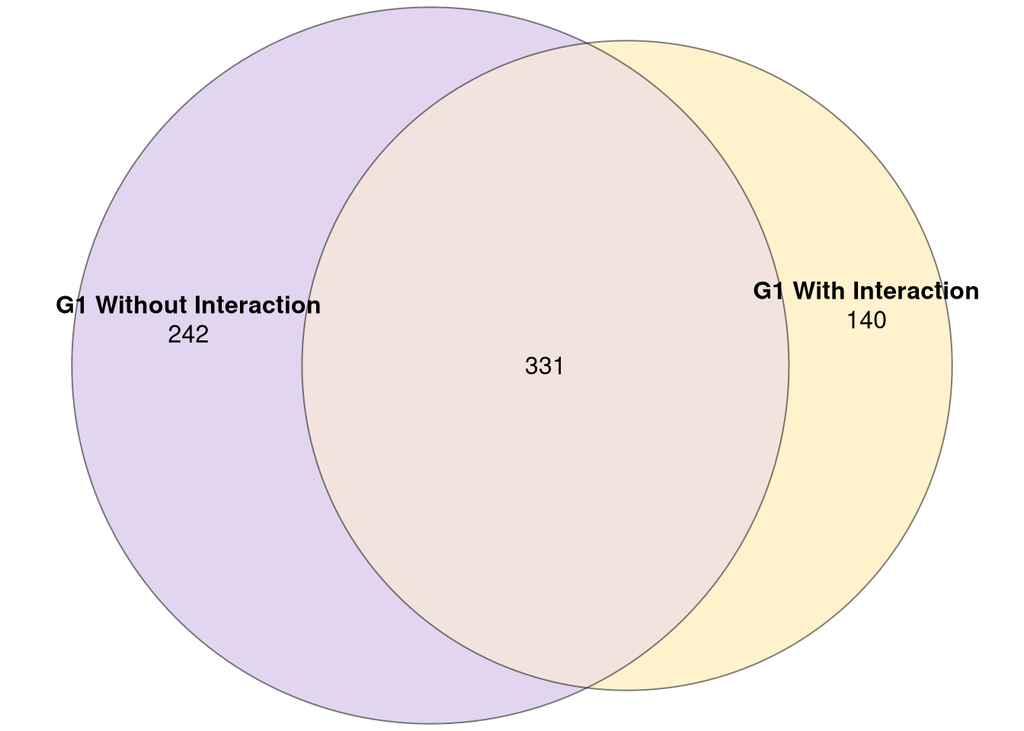

```r
# Generation 1
fit1 <- euler(c("G1 Without Interaction" = 242, "G1 With Interaction" = 140, "G1 Without Interaction&G1 With Interaction" = 331))

# Generation 2
fit2 <- euler(c("G2 Without Interaction" = 789, "G2 With Interaction" = 2746, "G2 Without Interaction&G2 With Interaction" = 3779))

# Generation 3
fit3 <- euler(c("G3 Without Interaction" = 485, "G3 With Interaction" = 602, "G3 Without Interaction&G3 With Interaction" = 749))

# Generation 4
fit4 <- euler(c("G4 Without Interaction" = 6, "G4 With Interaction" = 94, "G4 Without Interaction&G4 With Interaction" = 34))

plot(fit1, quantities = TRUE, fill = c("#c6abe0","#ffe599"),
     alpha=0.5,
     labels = list(font = 2))
```

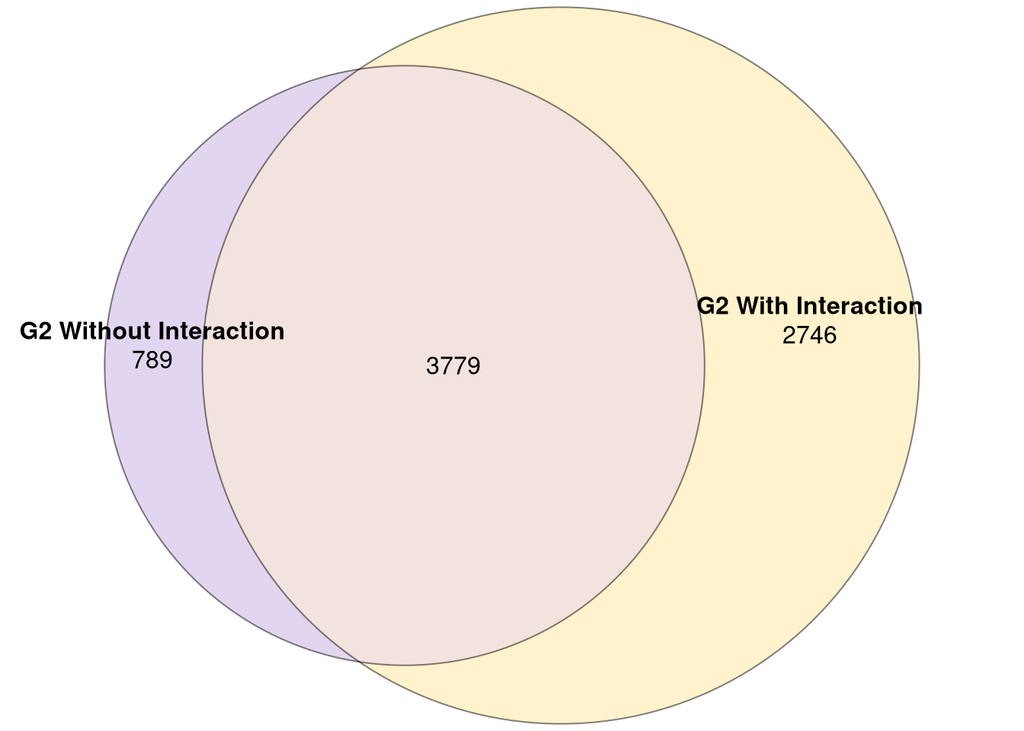

```r
plot(fit2, quantities = TRUE, fill = c("#c6abe0","#ffe599"),
     alpha=0.5,
     labels = list(font = 2))
```

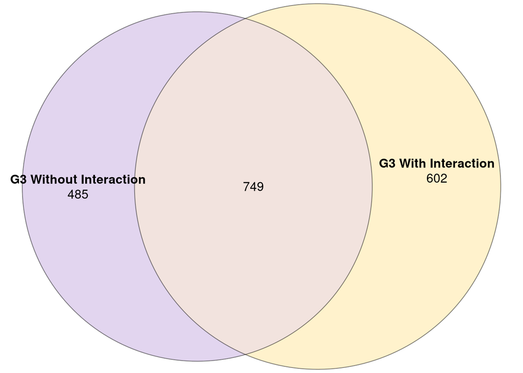

```r
plot(fit3, quantities = TRUE, fill = c("#c6abe0","#ffe599"),
     alpha=0.5,
     labels = list(font = 2))
```

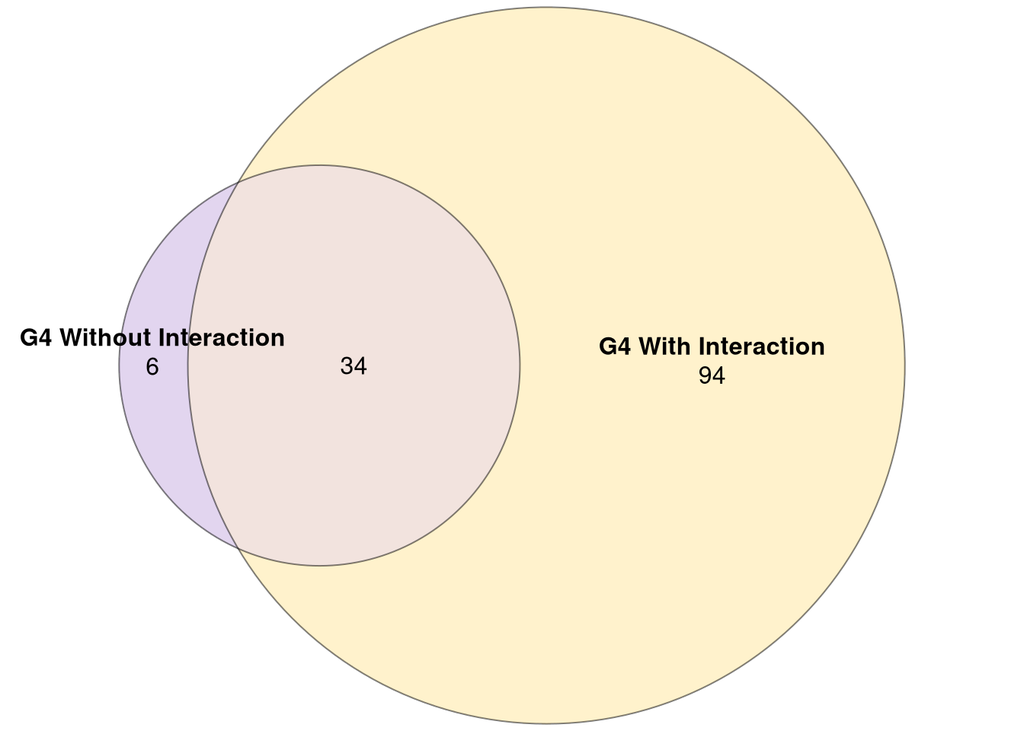

```r
plot(fit4, quantities = TRUE, fill = c("#c6abe0","#ffe599"),
     alpha=0.5,
     labels = list(font = 2))
```

Making the multipanel figure

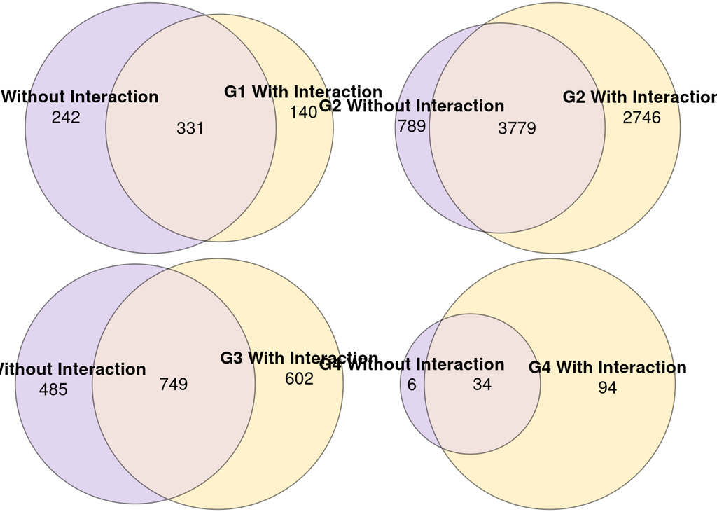

```r
# for arranging the plots
library(gridExtra)
grid.arrange(
  plot(fit1, quantities = TRUE, fill = c("#c6abe0","#ffe599"),
     alpha=0.5,
     labels = list(font = 2)),
  plot(fit2, quantities = TRUE, fill = c("#c6abe0","#ffe599"),
     alpha=0.5,
     labels = list(font = 2)),
  plot(fit3, quantities = TRUE, fill = c("#c6abe0","#ffe599"),
     alpha=0.5,
     labels = list(font = 2)),
  plot(fit4, quantities = TRUE, fill = c("#c6abe0","#ffe599"),
     alpha=0.5,
     labels = list(font = 2)),
  nrow=2
)
```

Another way of combining the Venns that compares generations by size

```r
fit <- euler(c("G1" = 242, "G1i" = 140, "G1&G1i" = 331,"G2" = 789, "G2i" = 2746, "G2&G2i" = 3779,"G3" = 485, "G3i" = 602, "G3&G3i" = 749,"G4" = 6, "G4i" = 94, "G4&G4i" = 34))

jpeg("Fig3.jpeg", width = 6, height = 5, units = 'in', res = 300)

plot(fit, quantities = TRUE, fill = c("#c6abe0","#ffe599","#c6abe0","#ffe599","#c6abe0","#ffe599","#c6abe0","#ffe599"),
     alpha=0.5,
     labels = list(font = 2))
```